# PACTA Portfolio Alignment Report

Paris Agreement Capital Transition Assessment

Mekong Commercial Bank (MCB) — Vietnam

Scenario: PDP8 2023 / Vietnam NDC / IEA NZE Global

Generated: September 02, 2026 | Framework: r2dii / pacta.loanbook | Base year: 2025 | Horizon: 2025–2030

## 1. Tóm tắt điều hành (Executive Summary)

43

Khoản vay  
Số lượng khoản vay

43

Khớp với ABCD  
Đã ghép ABCD

Rủi ro than  
Tỷ trọng điện than

NLTT xanh  
Tỷ trọng tái tạo

Xe điện (EV)  
Tỷ trọng VinFast

**Khuyến nghị ngay (Immediate Actions):** (1) Áp dụng tiêu chí phân loại tín dụng xanh theo hướng dẫn Ngân hàng Nhà nước (SBV); (2) Yêu cầu lộ trình chuyển đổi khí hậu từ THACO và Hoa Phat trước khi tái cấp vốn; (3) Mở rộng danh mục NLTT từ 13% lên 15–20% vào năm 2030.

## 2. Phương pháp luận PACTA (Methodology)

**PACTA (Paris Agreement Capital Transition Assessment)** là phương pháp đo lường sự phù hợp của danh mục cho vay với các mục tiêu khí hậu. Phương pháp này được phát triển bởi 2° Investing Initiative (2DII) và được sử dụng bởi hơn 6.000 tổ chức tài chính toàn cầu.

### Hai phương pháp đo lường

- **Phương pháp thị phần (Market Share):** Áp dụng cho ngành điện và ô tô. So sánh tỷ trọng công nghệ trong danh mục cho vay với mục tiêu kịch bản.
- **Phương pháp SDA (Sectoral Decarbonization Approach):** Áp dụng cho xi măng và thép. So sánh cường độ phát thải CO₂ (tCO₂/tấn sản phẩm) với lộ trình mục tiêu.

### Ba kịch bản so sánh

| Kịch bản | Nguồn | Mô tả | Phù hợp với |
| --- | --- | --- | --- |
| **STEPS / BAU** | IEA-phong cách | Chính sách hiện tại, không có hành động khí hậu mới | Mức cơ sở tham chiếu |
| **PDP8/NDC** | Quyết định 500/QĐ-TTg 2023 + NDC 2022 | Kế hoạch chính thức của Việt Nam; lộ trình than + NLTT đến 2030 | Chuẩn mực quốc gia |
| **NZE Global** | IEA Net Zero 2050 | Net zero toàn cầu vào 2050; tiêu chuẩn tham vọng nhất | Chuẩn mực quốc tế |

**Lưu ý về dữ liệu:** Tất cả dữ liệu loanbook và ABCD trong báo cáo này là *tổng hợp nhân tạo* (synthetic) để minh họa phương pháp. Dữ liệu thực tế cần lấy từ hệ thống quản lý tín dụng của ngân hàng và cơ sở dữ liệu tài sản đã kiểm định.

## 3. Danh mục cho vay MCB (MCB Loanbook Overview)

Mekong Commercial Bank (MCB) là ngân hàng thương mại cỡ vừa-lớn của Việt Nam (tổng tài sản ~500.000 tỷ VND, tương đương MB Bank hoặc Techcombank). Danh mục phân tích PACTA gồm **43 khoản vay** trong các lĩnh vực kinh tế thực có liên quan đến khí hậu.

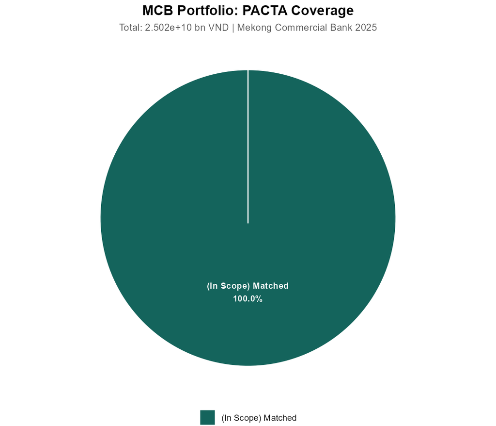

Phân bổ danh mục: PACTA coverage vs ngoài phạm vi

### Phân bổ danh mục theo lĩnh vực

[output not shown]

## 4. Phân tích ngành điện (Power Sector)

Ngành điện chiếm **63% danh mục MCB** (15,750 tỷ VND). Đây là lĩnh vực quan trọng nhất trong phân tích vì Việt Nam đang trong quá trình chuyển đổi năng lượng sâu sắc theo PDP8 và cam kết JETP.

**Bối cảnh PDP8:** Quyết định 500/QĐ-TTg (5/2023) quy định: không có nhà máy điện than mới sau 2030; than giảm xuống 26% công suất vào 2030; tái tạo (mặt trời + gió) đạt 74,8 GW vào 2030. JETP cam kết đỉnh phát thải điện năm 2030 và than dưới 30%.

### Cơ cấu công nghệ điện

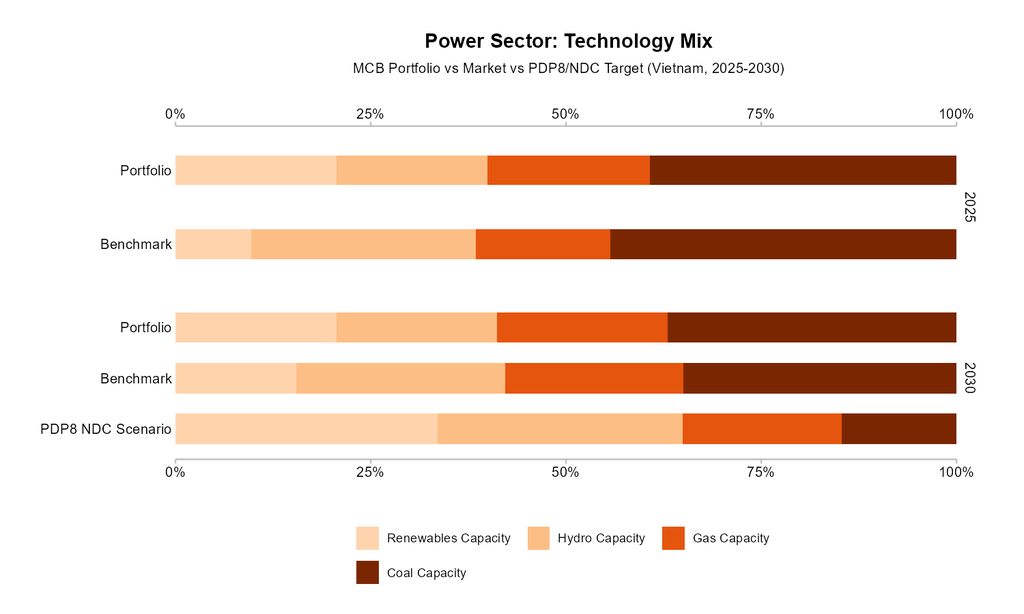

Cơ cấu công nghệ điện: MCB vs PDP8 target (2025-2030)

### Lộ trình điện than

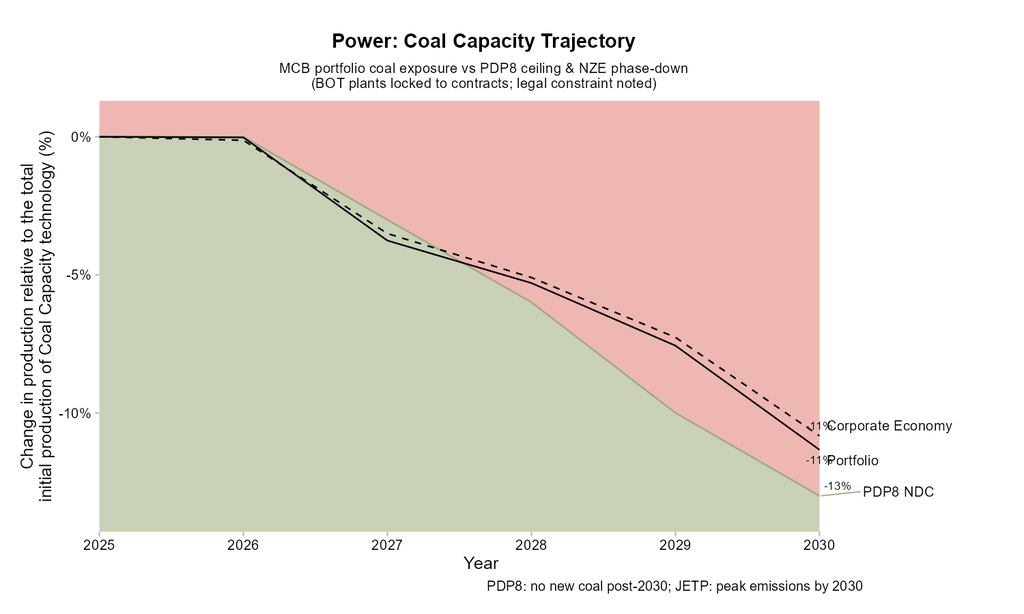

### Lộ trình năng lượng tái tạo

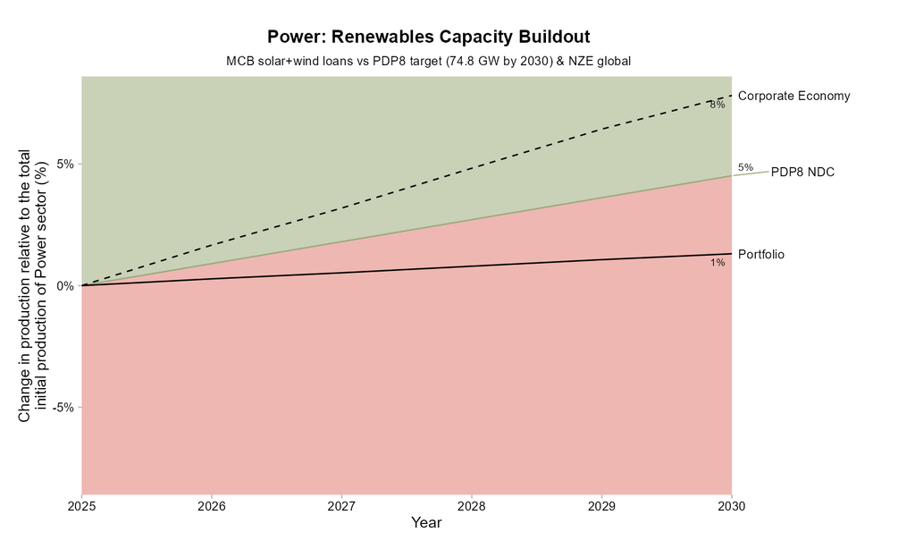

Năng lượng tái tạo: MCB portfolio (Trung Nam, BIM, TTC, Xuan Thien, T&T) vs PDP8

## 5. Phân tích ngành ô tô (Automotive Sector)

MCB có 4,500 tỷ VND cho vay ô tô (4,500 tỷ VND), trong đó THACO chiếm tỷ trọng lớn nhất (1,200 tỷ VND, 100% ICE). VinFast (EV 100%) chỉ chiếm 4% danh mục nhưng đại diện cho hướng tăng trưởng tương lai.

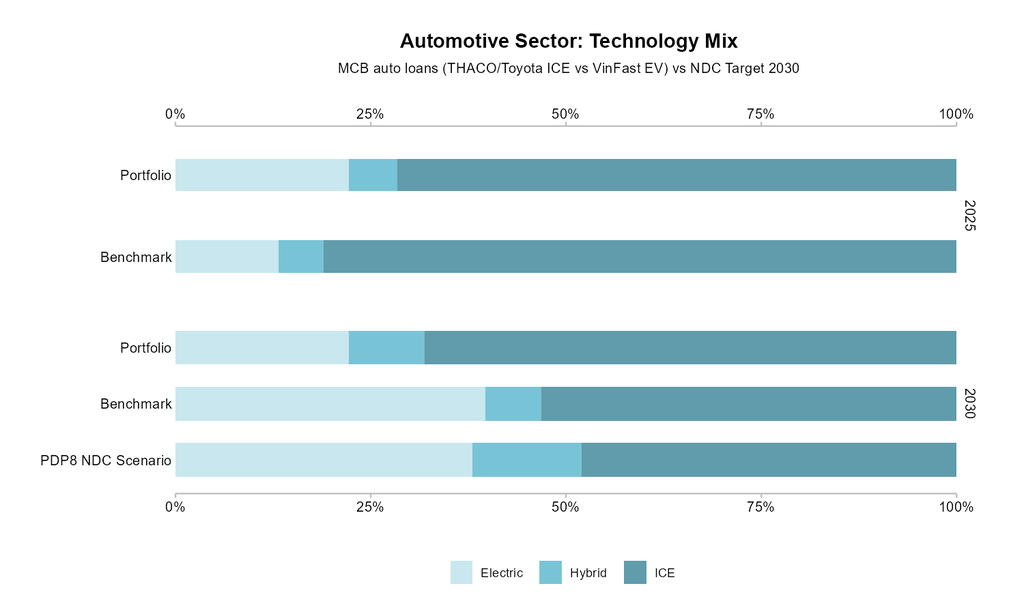

Cơ cấu công nghệ ô tô: MCB vs NDC target

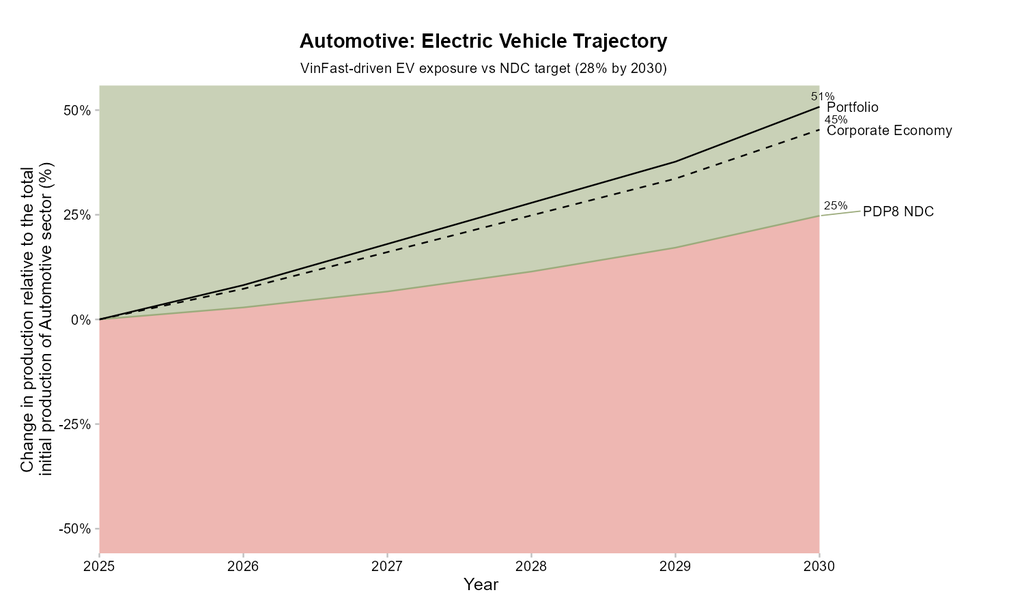

Lộ trình xe điện EV: VinFast-driven vs NDC target

## 6. Phân tích xi măng (Cement Sector)

Việt Nam là nước xuất khẩu xi măng lớn thứ 3 thế giới. MCB có 2000 tỷ VND cho vay xi măng (VICEM 1,200 tỷ + Holcim 800 tỷ). Cường độ phát thải trung bình: 0.82 tCO₂/tấn xi măng (cao hơn mức trung bình toàn cầu 0.60).

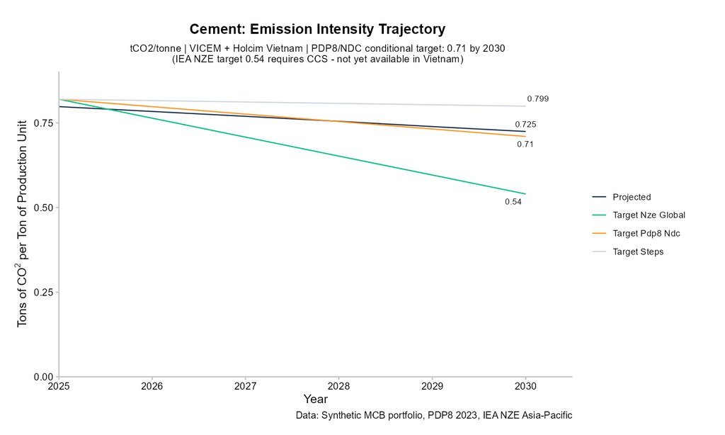

Xi măng: Lộ trình cường độ phát thải CO₂ (SDA Method)

## 7. Phân tích thép (Steel Sector)

MCB có 1,500 tỷ VND cho vay thép gồm hai doanh nghiệp với công nghệ rất khác nhau: **Hoa Phát** (lò cao/BOF, cường độ cao) và **Pomina** (lò điện hồ quang EAF, cường độ thấp). Phân tích này cho thấy sự khác biệt về rủi ro trong cùng một lĩnh vực.

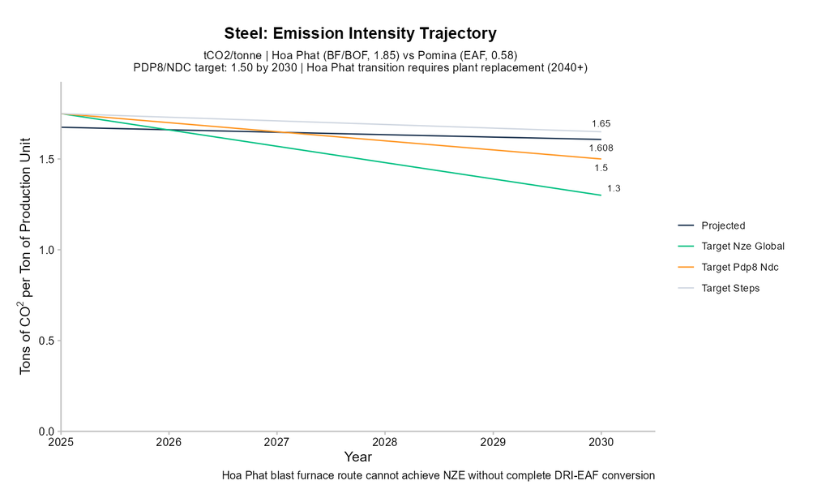

Thép: Cường độ phát thải CO₂ theo phương pháp SDA

**Hoa Phát - Rủi ro cao:** Lò cao/BOF của Hoa Phát: 1.85 tCO₂/tấn. Mục tiêu NDC 2030: 1.50 (khoảng cách 0.35). Không có kế hoạch chuyển đổi DRI-EAF trong 5 năm tới. Việc đạt NZE đòi hỏi thay thế toàn bộ nhà máy (2040+).

**Pomina - Phù hợp:** EAF của Pomina: 0.58 tCO₂/tấn. Đã phù hợp với mục tiêu NZE 2030. Minh họa rằng chất lượng danh mục thép phụ thuộc nhiều vào công nghệ luyện thép cụ thể.

## 8. Tổng quan căn chỉnh (Alignment Summary)

Bảng tổng hợp kết quả căn chỉnh danh mục MCB đối với kịch bản PDP8/NDC Việt Nam tại năm 2030. Phân tích dựa trên **phương pháp thị phần** (ngành điện, ô tô) và **phương pháp SDA** (xi măng, thép).

| Sector | Technology | Method | Projected 2030 | PDP8 Target 2030 | Gap | Status |
| --- | --- | --- | --- | --- | --- | --- |
| automotive | electric | Market Share | 22.2% | 38.1% | -15.83 pp | Misaligned |
| automotive | hybrid | Market Share | 9.7% | 14% | -4.27 pp | Misaligned |
| automotive | ice | Market Share | 68.1% | 48% | +20.1 pp | Misaligned |
| power | coalcap | Market Share | 37% | 14.7% | +22.28 pp | Misaligned |
| power | gascap | Market Share | 21.9% | 20.3% | +1.55 pp | Misaligned |
| power | hydrocap | Market Share | 20.5% | 31.4% | -10.86 pp | Misaligned |
| power | renewablescap | Market Share | 20.6% | 33.6% | -12.96 pp | Misaligned |
| cement | cement intensity | SDA | 0.725 | 0.71 | +2.1% | Misaligned |
| steel | steel intensity | SDA | 1.608 | 1.5 | +7.2% | Misaligned |

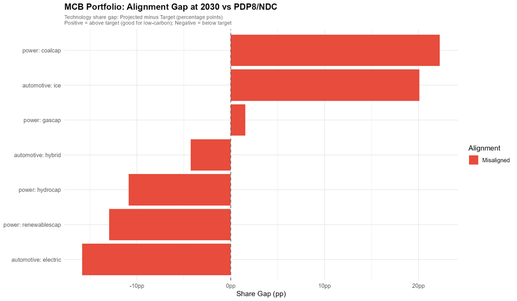

Khoảng cách căn chỉnh theo lĩnh vực vs PDP8/NDC tại 2030

### Bảng tín hiệu giao thông (Traffic Light Summary)

[output not shown]

## 9. Rủi ro tài sản mắc kẹt (Stranded Asset Risk)

JETP và lộ trình PDP8 tạo ra rủi ro tài sản mắc kẹt đáng kể đối với danh mục than của MCB. Cơ chế nghỉ hưu than (Coal Retirement Mechanism) nhắm vào 5–8 GW than đóng cửa sớm vào năm 2035.

[figure not shown]

Phơi nhiễm than và khai thác theo nhóm mẹ (tỷ VND)

[output not shown]

**BOT Lock-in:** Nhà máy Nghi Son 2 (Marubeni/KEPCO) và Mong Duong 2 (International Power) có hợp đồng PPA đảm bảo thanh toán công suất đến ~2035. Nghỉ hưu sớm đòi hỏi gói mua lại từ chính phủ — chi phí ước tính 200–400 triệu USD/nhà máy. Điều này làm phức tạp phân tích căn chỉnh vì công suất than không thể giảm trước ngày hết hạn PPA.

## 10. Khuyến nghị hành động (Recommendations)

### Trung hạn (2027–2030): Tái cân bằng danh mục

- Mở rộng **tín dụng xanh**: mục tiêu NLTT từ 13% lên 15–20% danh mục. Ưu tiên gió ngoài khơi (PDP8: 6 GW đến 2030).
- Tăng **cho vay VinFast và chuỗi cung ứng EV**: nhà cung cấp pin, trạm sạc, linh kiện điện tử.
- Hợp tác **JETP**: tham gia Cơ chế nghỉ hưu than như bên cho vay trong các gói tái cấu trúc tài chính cho EVN và Vinacomin Power.
- Phát triển **sản phẩm tài chính bền vững**: trái phiếu xanh (green bond), cho vay liên kết bền vững (SLL) cho THACO/Toyota VN.

### Dài hạn (2030+): Định vị chiến lược

- Trở thành **ngân hàng xanh hàng đầu Việt Nam** với 25–30% danh mục tài sản khí hậu vào 2035.
- Tích hợp **phân tích PACTA vào ICAAP** (Internal Capital Adequacy Assessment Process) và báo cáo TCFD.
- Xây dựng **cơ sở dữ liệu ABCD nội bộ** từ báo cáo thường niên của khách hàng — không phụ thuộc vào dữ liệu toàn cầu.

**PACTA Vietnam Report — Mekong Commercial Bank (Synthetic / Illustrative)**  
Framework: r2dii.analysis / r2dii.match / r2dii.plot / pacta.loanbook | Scenario: PDP8 Decision 500/QĐ-TTg (2023), Vietnam NDC 2022, IEA NZE 2050  
Generated: September 02, 2026 | *All data is synthetic for methodology demonstration. Not for investment decisions.*